## PHÂN TÍCH ExWAS đề kháng insulin

### Cài đặt devtools / BiocManager

```r
if (!requireNamespace("devtools", quietly = TRUE))
  install.packages("devtools")
if (!requireNamespace("BiocManager", quietly=TRUE))
  install.packages("BiocManager")
```

### Cài đặt rexposome dependencies

```r
packages = c('Biobase', 'mice', 'MultiDataSet', 'lsr', 'FactoMineR',
    'stringr', 'circlize', 'corrplot', 'ggplot2', 'reshape2', 'pryr',
    'scales', 'imputeLCMD', 'scatterplot3d', 'glmnet', 'gridExtra',
    'grid', 'Hmisc', 'gplots', 'gtools', 'S4Vectors', 'MASS'
)
for( pkg in packages ) {
  if( !pkg %in% rownames( installed.packages() ) ) {
    message( "Installing ", pkg )
    BiocManager::install( pkg )
  }
}
```

### cài đặt rexposome

```r
if (!requireNamespace("rexposome", quietly = TRUE)) {
  message("rexposome chưa được cài, tiến hành cài đặt...")
  devtools::install_github("isglobal-brge/rexposome")
} else {
  message("rexposome đã được cài đặt.")
}
```

### Nạp vào những gói cần thiết

**Các gói cơ bản**

```r
library(tidyverse)   # xử lý, trực quan hóa dữ liệu
library(readxl)      # đọc file Excel (.xlsx)
library(writexl)     # một package khác để xuất file excel
library(psych)       # thống kê mô tả, kiểm định tâm lý
library(car)         # hồi quy, kiểm định mở rộng
library(mice)        # bù dữ liệu thiếu
library(naniar)      # kiểm tra & trực quan hóa dữ liệu thiếu
library(xtable)      # Chuyển bảng dữ liệu thành bảng LaTeX hoặc HTML (phục vụ xuất báo cáo)
library(gridExtra)   # Sắp xếp và kết hợp nhiều biểu đồ ggplot2 trên cùng một trang
library(Cairo)       # Xuất đồ họa chất lượng cao (PDF, PNG, SVG) với chống răng cưa và hỗ trợ in ấn
```

**Các gói cần cho phân tích ExWAS**

```r
library(rexposome)      # Phân tích exposome: xử lý, mô tả và kiểm định liên quan exposome-kết cục
library(MASS)           # Hỗ trợ mô hình thống kê và phép biến đổi dữ liệu (ví dụ: Box-Cox)
library(MultiDataSet)   # Quản lý và tích hợp nhiều bộ dữ liệu omic hoặc exposome trong một đối tượng
library(corrplot)
```

### Thiết lập đường dẫn

```r
path <- "../../data"
expof <- file.path(path, "exposome_data/exposures.csv")
descf <- file.path(path, "exposome_data/description.csv")
phenf <- file.path(path, "exposome_data/phenotypes.csv")
```

### Tạo ExposomeSet object

```r
inre_exp<-readExposome(
  exposures=expof,
  description=descf,
  phenotype=phenf,
  sep= ",",
  description.famCol="family",
  description.expCol="exposure",
  exposures.samCol="sub_id",
  phenotype.samCol="sub_id"
)
dim(inre_exp) # (237: 34) + 5
```

```
## exposures   samples phenotyes
##        34       237         5
```

### Khám phá cấu trúc của ExposomeSet object

```r
# truy cập tên các đối tượng quan sát
head(sampleNames(inre_exp))
```

```
## [1] "100" "113" "137" "138" "14"  "144"
```

```r
# truy cập vào các biến số phơi nhiễm
exposureNames(inre_exp)
```

```
##  [1] "Calcium"               "Calories"              "Crude.fat"
##  [4] "Crude.protein"         "Cholesterol"           "Dairy..fullfat."
##  [7] "Dairy..skim...lowfat." "Dietary.fiber"         "Disaccharides"
## [10] "EAA"                   "Fruit"                 "Iron"
## [13] "Magnesium"             "Monosaccharides"       "NEAA"
## [16] "PLMF"                  "Potassium"             "Phosphorus"
## [19] "PHSF"                  "Seeds"                 "Sodium"
## [22] "TFA_M"                 "TFA_P"                 "TFA_S"
## [25] "Total.carbohydrate"    "Trans.fat"             "Vegetable"
## [28] "VitA"                  "VitB"                  "VitC"
## [31] "VitE"                  "Water"                 "Whole.Rhizome"
## [34] "Zinc"
```

```r
# truy cập vào tên family trong description
familyNames(inre_exp)
```

```
## [1] "Ions"                        "Calories"
## [3] "Fat"                         "Protein"
## [5] "Diary"                       "Water & Fruits & Vegetables"
## [7] "Carbohydrates"               "Vitamins"
```

```r
# truy cập vào confounder và outcome
phenotypeNames(inre_exp)
```

```
## [1] "sex"            "age"            "zbmi"           "calories.kcal."
## [5] "insulin_re"
```

```r
# truy cập vào toàn bộ file descf
fData(inre_exp)
```

```
##                                            Family
## Calcium                                      Ions
## Calories                                 Calories
## Crude.fat                                     Fat
## Crude.protein                             Protein
## Cholesterol                                   Fat
## Dairy..fullfat.                             Diary
## Dairy..skim...lowfat.                       Diary
## Dietary.fiber         Water & Fruits & Vegetables
## Disaccharides                       Carbohydrates
## EAA                                       Protein
## Fruit                 Water & Fruits & Vegetables
## Iron                                         Ions
## Magnesium                                    Ions
## Monosaccharides                     Carbohydrates
## NEAA                                      Protein
## PLMF                                      Protein
## Potassium                                    Ions
## Phosphorus                                   Ions
## PHSF                                      Protein
## Seeds                                         Fat
## Sodium                                       Ions
## TFA_M                                         Fat
## TFA_P                                         Fat
## TFA_S                                         Fat
## Total.carbohydrate                  Carbohydrates
## Trans.fat                                     Fat
## Vegetable             Water & Fruits & Vegetables
## VitA                                     Vitamins
## VitB                                     Vitamins
## VitC                                     Vitamins
## VitE                                     Vitamins
## Water                 Water & Fruits & Vegetables
## Whole.Rhizome                       Carbohydrates
## Zinc                                         Ions
##                                                               description .fct
## Calcium                                                    Calcium intake
## Calories                                             Total energy intake
## Crude.fat                                                Total fat intake
## Crude.protein                                       Total protein intake
```

[output cut: 50 more lines]

```
## Seeds                                numeric
## Sodium                               numeric
## TFA_M                                numeric
## TFA_P                                numeric
## TFA_S                                numeric
## Total.carbohydrate                   numeric
## Trans.fat                            numeric
## Vegetable                            numeric
## VitA                                 numeric
## VitB                                 numeric
## VitC                                 numeric
## VitE                                 numeric
## Water                                numeric
## Whole.Rhizome                        numeric
## Zinc                                 numeric
```

```r
# truy cập vào bảng dữ liệu phenotypes
head(pData(inre_exp), n = 3)
```

```
##     sex   age  zbmi calories.kcal. insulin_re
## 100   0  8.93 -1.56       2290.576         no
## 113   1 12.92 -1.12       1907.338         no
## 137   0  9.59  0.88       1765.770         no
```

### Kiểm tra missing data

```r
tableMissings(inre_exp, set = "exposures", output = "n")
```

```
##               Calcium              Calories             Crude.fat
##                     0                     0                     0
##         Crude.protein           Cholesterol       Dairy..fullfat.
##                     0                     0                     0
## Dairy..skim...lowfat.         Dietary.fiber         Disaccharides
##                     0                     0                     0
##                   EAA                 Fruit                  Iron
##                     0                     0                     0
##             Magnesium       Monosaccharides                  NEAA
##                     0                     0                     0
##                  PLMF             Potassium            Phosphorus
##                     0                     0                     0
##                  PHSF                 Seeds                Sodium
##                     0                     0                     0
##                 TFA_M                 TFA_P                 TFA_S
##                     0                     0                     0
##    Total.carbohydrate             Trans.fat             Vegetable
##                     0                     0                     0
##                  VitA                  VitB                  VitC
##                     0                     0                     0
##                  VitE                 Water         Whole.Rhizome
##                     0                     0                     0
##                  Zinc
##                     0
```

```r
tableMissings(inre_exp, set = "phenotypes", output = "n")
```

```
##            sex            age           zbmi calories.kcal.     insulin_re
##              0              0              0              0              0
```

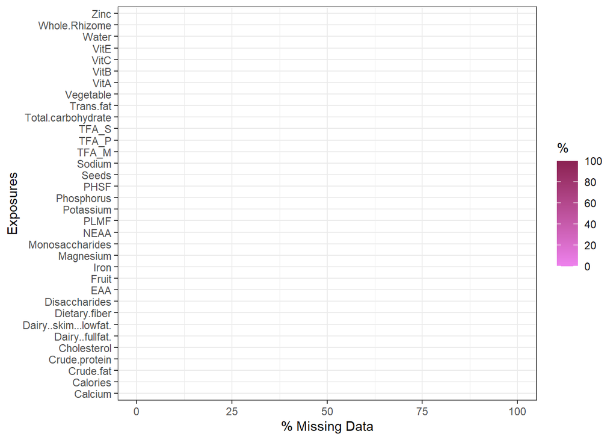

```r
plotMissings(inre_exp, set = "exposures")
```

### Kiểm định phân phối chuẩn

```r
nm <- normalityTest(inre_exp)
table(nm$normality)
```

```
##
## FALSE  TRUE
##    31     3
```

```r
nm$exposure[!nm$normality]
```

```
##  [1] "Iron"                  "VitC"                  "VitA"
##  [4] "Dairy..skim...lowfat." "Calcium"               "Magnesium"
##  [7] "PHSF"                  "Fruit"                 "Potassium"
## [10] "Dairy..fullfat."       "Monosaccharides"       "VitE"
## [13] "Trans.fat"             "Disaccharides"         "TFA_P"
## [16] "Cholesterol"           "TFA_M"                 "TFA_S"
## [19] "EAA"                   "Vegetable"             "NEAA"
## [22] "Zinc"                  "Dietary.fiber"         "VitB"
## [25] "Sodium"                "Phosphorus"            "Water"
## [28] "PLMF"                  "Seeds"                 "Crude.fat"
## [31] "Crude.protein"
```

Có 3 biến exposures phân phối chuẩn, còn lại không phân phối chuẩn

### Trực quan hóa dữ liệu exposures

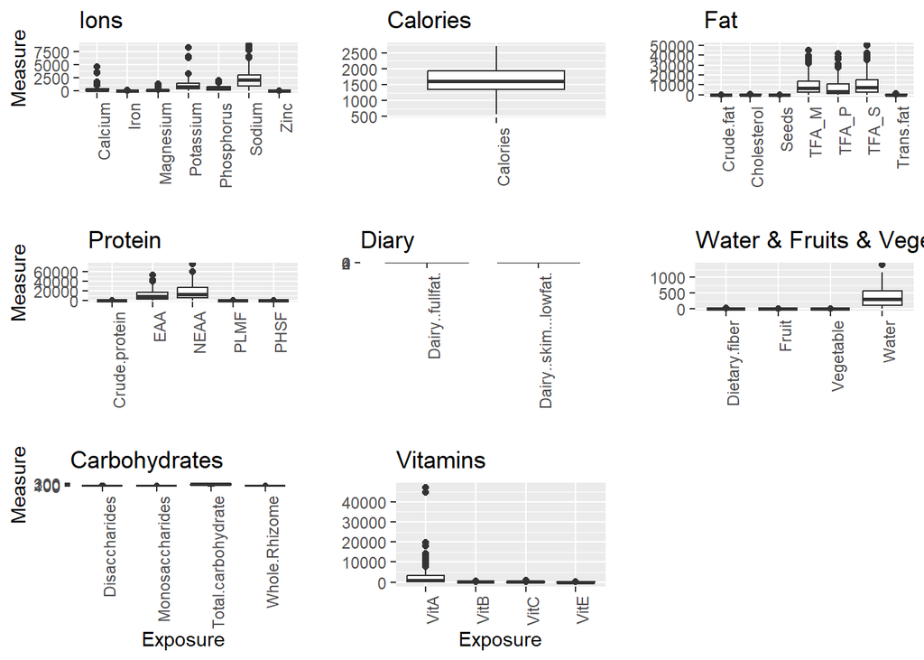

```r
# vẽ box-plot cho tất cả các exposures theo family
plotFamily(inre_exp, family = "all")
```

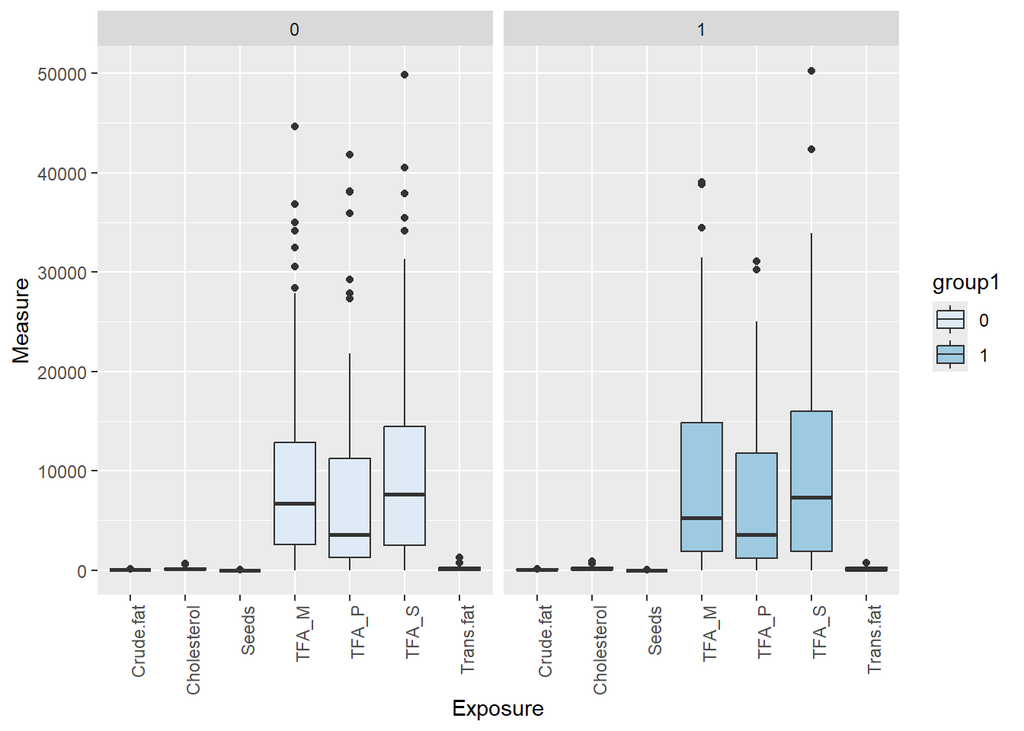

```r
# vẽ box-plot các exposure theo nhóm biến confounder
plotFamily(inre_exp, family = "Fat", group = "sex", group2 = "sex")
```

### Just for fun - thử vẽ biểu đồ sau khi đã chuẩn hóa dữ liệu

```r
exp_std <- standardize(inre_exp, method = "normal")
```

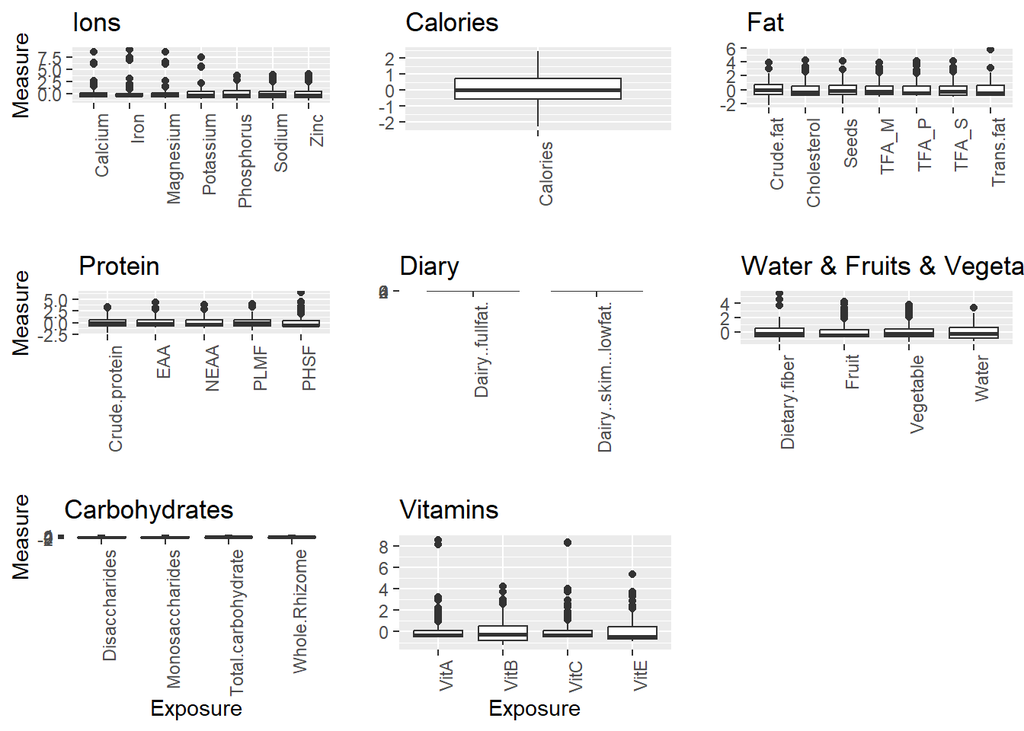

```r
plotFamily(exp_std, family = "all")
```

**Câu hỏi**

- Theo doc, hàm standardize chỉ áp dụng lên các exposures
- Vậy các biến confounder thì có cần standardize không, và làm như thế nào
- Làm thế nào để biểu đồ trên đẹp hơn

### Normalization dữ liệu

```r
expo_best_trans <- function(var) {
  var[var == 0] <- 0.00001 #to avoid problems with log(0)
  bc <- boxcox(var ~ 1, plotit = FALSE)
  trans <- bc$x[which.max(bc$y)]
  if (trans < (-1.5)) {
    x <- 1/(var^2)
  } else if (trans < (-0.75) & trans > (-1.5)) {
    x <- 1/(var)
  } else if (trans < (-0.25) & trans > (-0.75)) {
    x <- 1/(sqrt(var))
  } else if (trans < (0.25) & trans > (-0.25)) {
    x <- log(var)
  } else if (trans < (0.75) & trans > (0.25)) {
    x <- sqrt(var)
  } else if (trans < (1.5) & trans > (0.75)) {
    x <- var
  } else {
    x <- var^2
  }
  return(x)
}

inre_exp_t <- trans(inre_exp, fun=expo_best_trans, by.exposure=TRUE)
```

**Câu hỏi**

- Các biến confounder có cần normalize không và tại sao
- Làm sao để thực hiện được điều này

### Standardization dữ liệu

```r
inre_exp_s <- standardize(inre_exp_t, method="normal")
inre_exp_s
```

```
## Object of class 'ExposomeSet' (storageMode: environment)
##  . exposures description:
##     . categorical:  0
##     . continuous:  34
##  . exposures transformation:
##     . categorical: 0
##     . transformed: 34
##     . standardized: 34
##     . imputed: 0
##  . assayData: 34 exposures 237 individuals
##     . element names: exp
##     . exposures: Calcium, ..., Whole.Rhizome
##     . individuals: none
##  . phenoData: 237 individuals 5 phenotypes
##     . individuals: 100, ..., w0093
##     . phenotypes: sex, ..., calories.kcal.
##  . featureData: 34 exposures 7 explanations
##     . exposures: Calcium, ..., Whole.Rhizome
##     . descriptions: Family, ..., .imp
## experimentData: use 'experimentData(object)'
## Annotation:
```

**Câu hỏi**

- Tại sao dùng phương pháp “normal”mà không dùng Spearman-based scaling như trong bài báo
- Khi nào thì nên chọn cái nào